# EU-ForDAM: what we have so far

Species ranking, correlation metrics and gap-filling, in plain words

Published

October 20, 2026

## The question

The thesis rests on one idea: **damage from different insects tends to rise and fall together, so the records we have carry information about the ones that are missing.** Everything below tests that idea and then uses it.

| Step | Question | Thesis objective |
| --- | --- | --- |
| 1. Species ranking | Which insects cause damage in the most regions? | 2 (damage across agents) |
| 2. Correlation metrics | Do insects really rise and fall together? | the premise; 3 (patterns) |
| 3. Gap-filling | Can we use that to fill the missing records? | 1 (harmonise records), then 2 (Europe-wide totals) |

**Data and rules used throughout.** EU-ForDAM, 16 countries, 77 regions (NUTS units), 2000-2022. `value1` only (`value2` is the same damage in another unit). 0 = monitored, no damage; not reported = unknown (never treated as 0).

**Groups follow the 2025 EU-ForDAM paper (Table 1).**

| Level | What | Groups |
| --- | --- | --- |
| 1 | feeding guild x host type | Borers / Defoliators on gymnosperms / angiosperms |
| 2 | gymnosperm host | Borers on *P. abies*, *P. sylvestris*, *A. alba*; Defoliators on *P. abies*, *P. sylvestris* |
| 3 | single insects | 43 codes (species, genera, and the species group “Geometridae on oaks”) |

Some codes are **aggregates**: several insects reported together (e.g. `CambXyl_con&BO` = “borers on pine”). As in the paper, they count **only in the group totals** (levels 1-2). They are never ranked, correlated or gap-filled as if they were one insect. The spruce bark-borer group (`CambXyl_con&BB_con&SM`, Czechia and Germany) is mostly *Ips typographus* and is counted as *I. typographus*, again as in the paper. `tha_pit` is *Thaumetopoea pityocampa* (the paper’s name). The code-to-group table is `data/lookup/paper_hierarchy_2025.csv`.

**Check against the paper.** Our cumulative totals reproduce the paper’s Table 2 closely: *I. typographus* to 0.01%, Borers on angiosperms exactly, *P. chalcographus* exactly, Borers on *P. abies* within 2% (the paper’s total appears not to include *Trypodendron lineatum*, which is in our data and counted here). The rest are within 0-9% (defoliators slightly higher in our file, probably later data corrections; the paper used 15 countries). Table: `outputs/tables/CHECK_totals_vs_paper_table2.csv`.

## 1. Species-NUTS occurrence ranking

Three graphs, one per level of the 2025 paper.

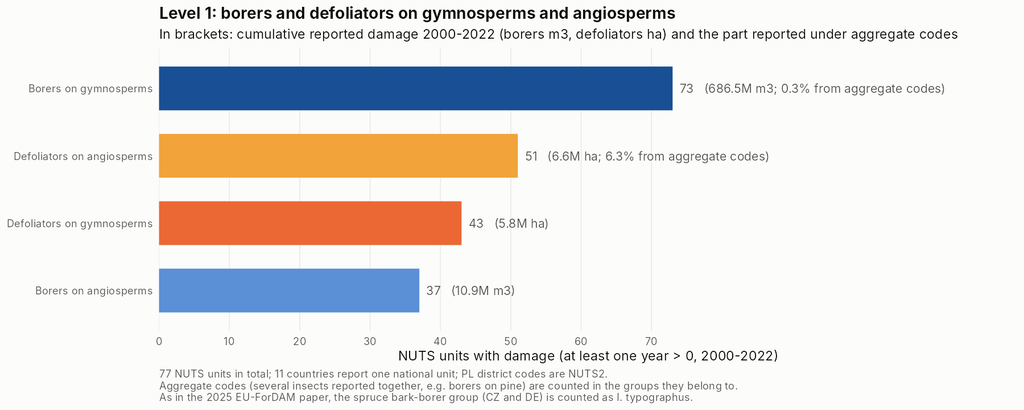

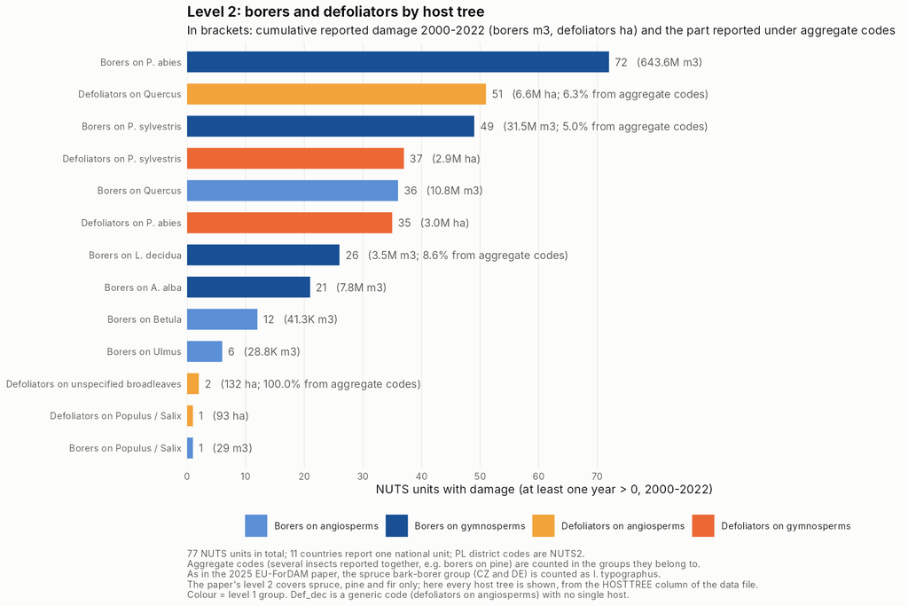

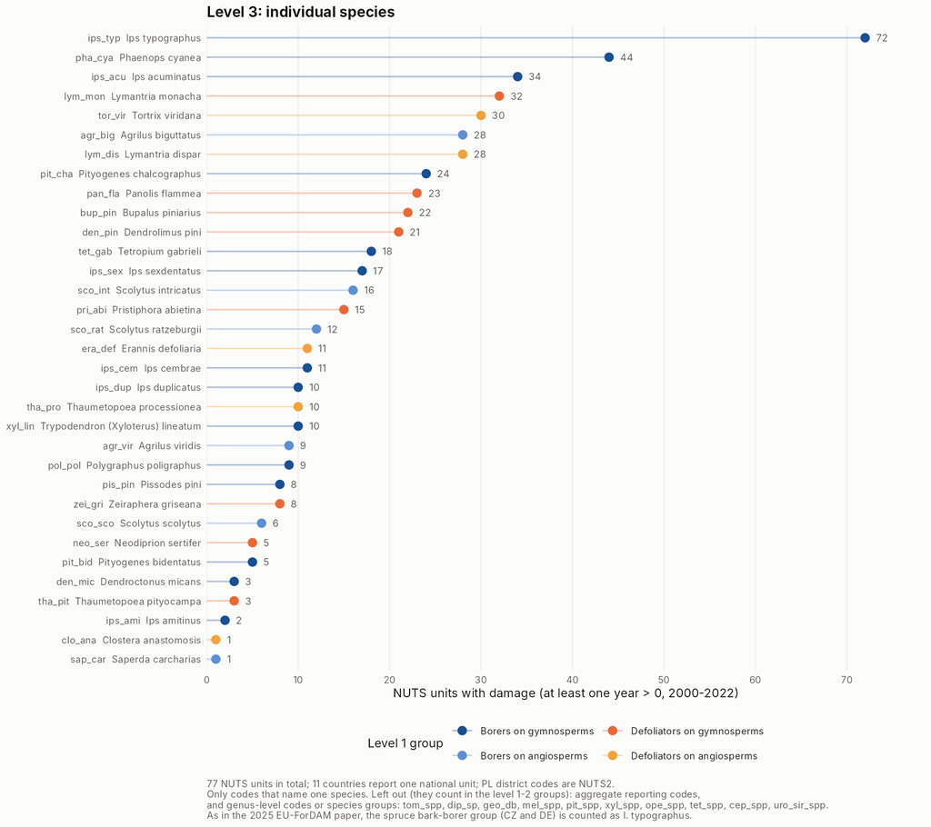

How much damage each species caused (reported, 2000-2022):

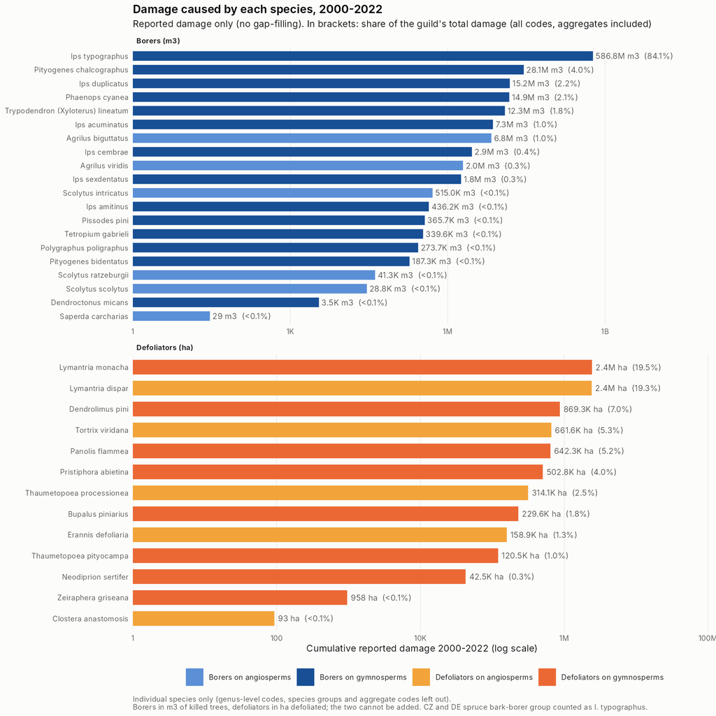

- **Borers:** *Ips typographus* alone caused 84% of all borer damage (587 million m3), as in the paper (85.8%). Next: *Pityogenes chalcographus* (4%), *Ips duplicatus* (2.2%), *Phaenops cyanea* (2.1%).
- **Defoliators** are much more even: *Lymantria monacha* and *L. dispar* about 19% each, then *Dendrolimus pini* (7%), *Tortrix viridana* and *Panolis flammea* (5% each).
- Being widespread is not the same as causing much damage: *Ips acuminatus* is in 34 regions but causes only 1% of borer damage; *Ips duplicatus* is in 10 regions and causes 2.2%.
- **Level 1:** Borers on gymnosperms cause damage in **73 of 77** regions; defoliators on angiosperms are next (51).
- **Level 2, every host tree:** borers on spruce (*P. abies*) lead with 72 regions and 644 million m3, then defoliators on oak (*Quercus*, 51), borers on pine (49), defoliators on pine (37), borers on oak (36), defoliators on spruce (35), borers on larch (26) and borers on fir (21). Birch, elm and poplar/willow insects are rare (1-12 regions). The paper’s own level 2 covers spruce, pine and fir only; the other host trees come from the data file’s host-tree column.
- **Aggregates are inside the groups now**, not ranked as insects. They are a small part of each group: 0.3% of Borers on gymnosperms, 5% of Borers on *P. sylvestris*, 6% of Defoliators on angiosperms.
- **Level 3, individual species** (33 codes that name one species; genus-level codes such as *Tomicus* spp. and the aggregates count only in the groups): *Ips typographus* is everywhere (72 regions, all 16 countries). Next: *Phaenops cyanea* (44), *Ips acuminatus* (34), *Lymantria monacha* (32), *Tortrix viridana* (30). Most species are local: half cause damage in 11 regions or fewer.

## 2. Correlation metrics: do insects rise and fall together?

**How.** For every pair of single insects (43 insects, 903 pairs; aggregates left out), in the same region and year: does one have a bad year when the other does? Each region is compared with its own normal (so big and small regions count the same). A link is **sure** if it survives resampling whole regions 999 times, and **strong** if r is at least 0.3.

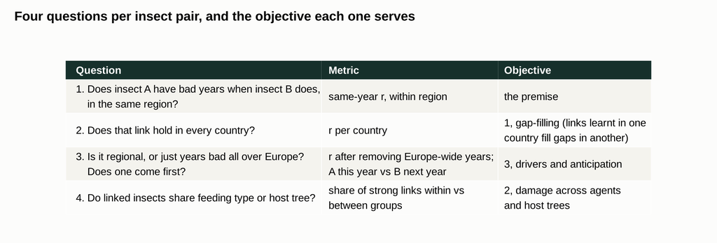

### The heatmap

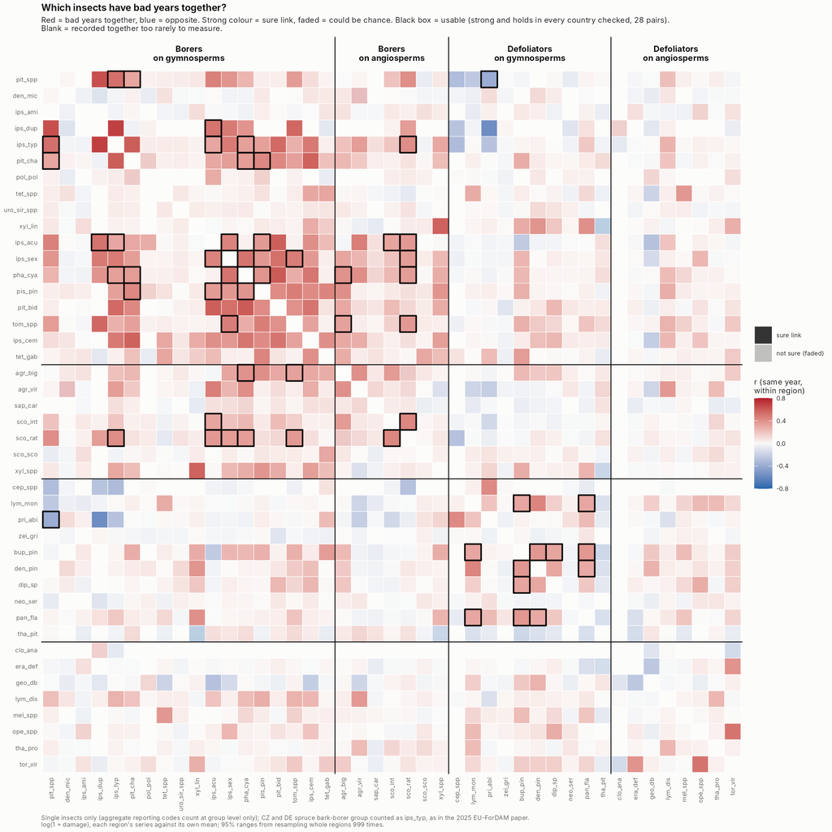

Red = bad years together. Strong colour = sure link; faded = could be chance; black box = usable. The red block top left is the bark and wood borers on conifers.

### One verdict per pair

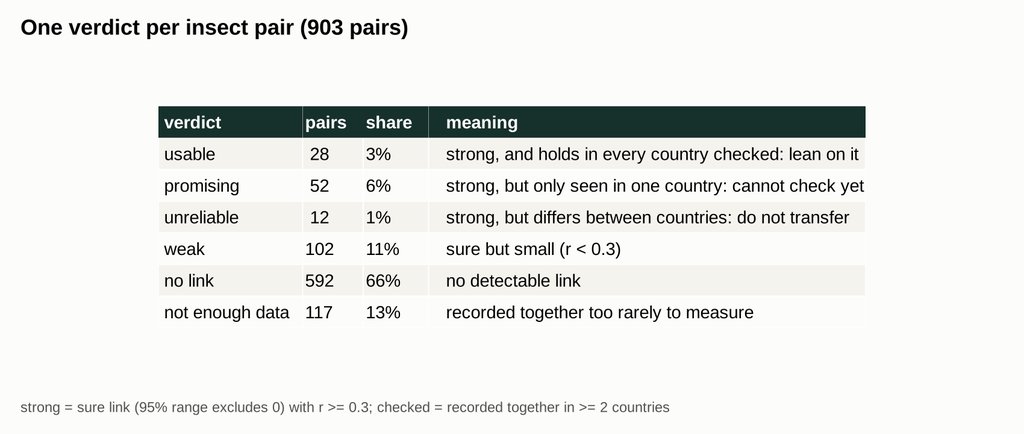

**28 usable pairs**: strong and the same in every country where they can be checked. About 12% of measurable pairs are strongly linked. (Before the retool there were 30; the two that dropped out were aggregate x insect pairs, which compared a group with its own members.)

### The 28 usable pairs

[figure not shown]

### Key findings

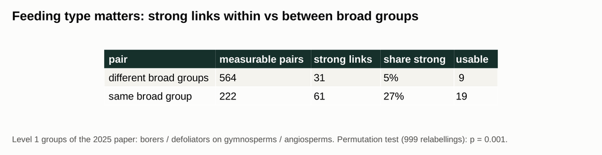

### The heatmaps at the paper’s three levels

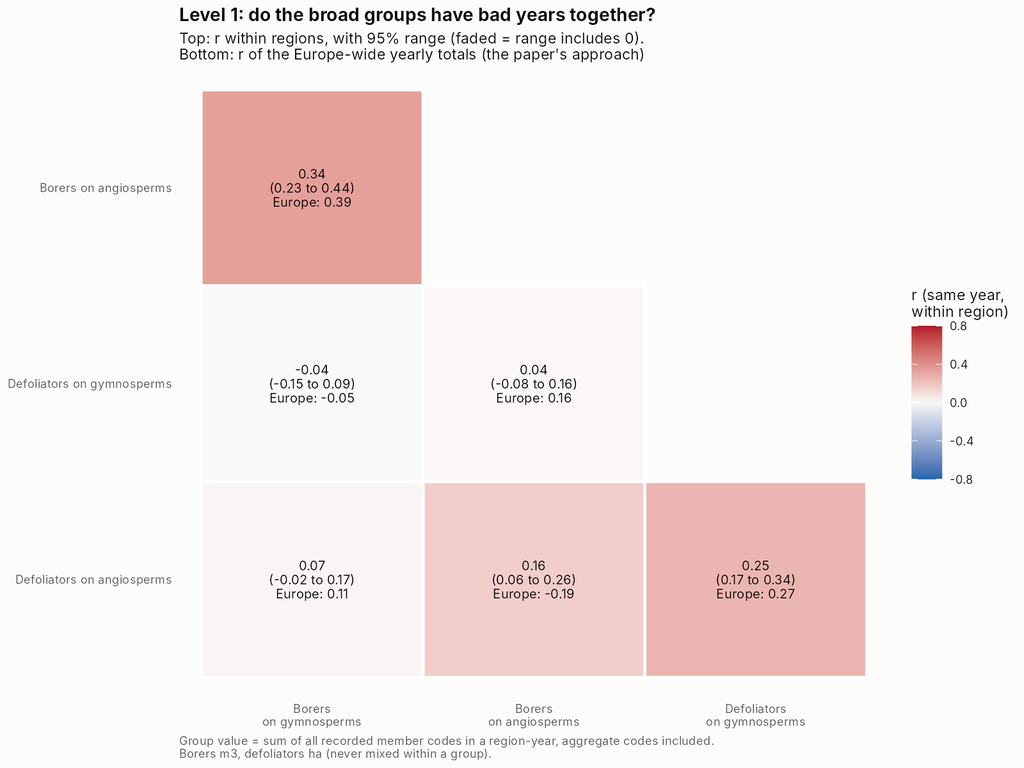

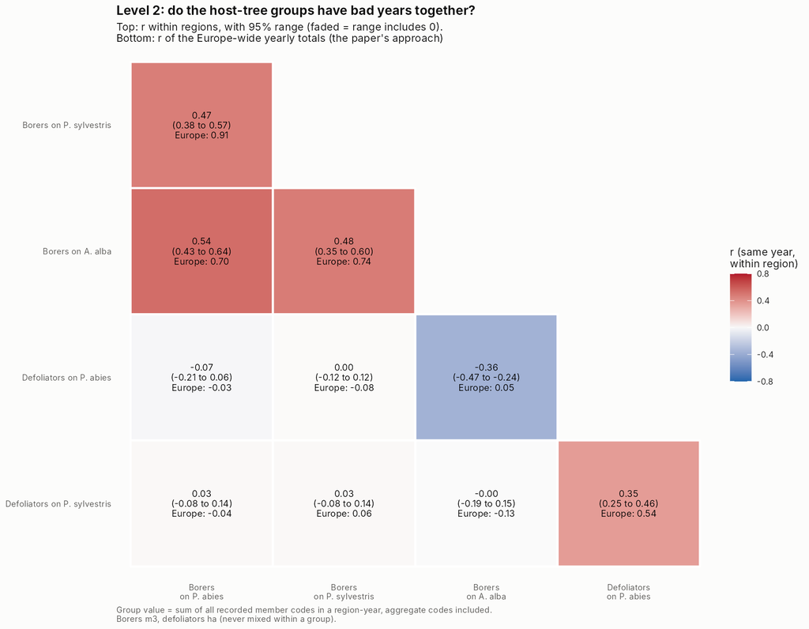

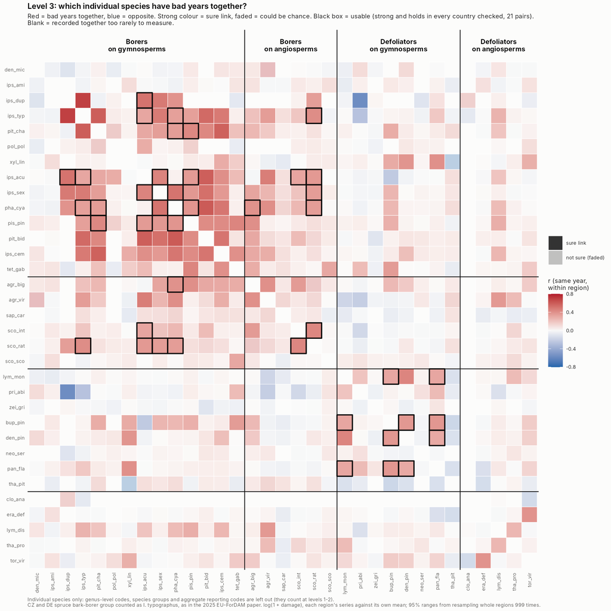

Level 3 shows individual species only (33 species, 528 pairs, 21 of them usable). The full verdicts above also include genus-level codes such as *Tomicus* spp. (43 insects, 28 usable pairs).

Here the group series include the aggregates. Bark borers on spruce, pine and fir have bad years together (r 0.47-0.54 within regions; 0.70-0.91 for the Europe-wide totals, the paper’s way). Spruce and pine defoliators go together (0.35). Borers and defoliators do **not** move together, and fir borers go **against** spruce defoliators (-0.36). Table: `CM_groups_level1_level2.csv`.

## 3. Gap-filling with a latent factor model

### How it works (plain words)

Each empty box (region x year x insect) gets two questions, multiplied together:

1. **Was there any damage?** (a chance)
2. **If yes, how much?** (an amount per 1,000 ha of host forest, scaled by the region’s forest)

The model learns a few hidden “scores” for each region-year (e.g. *was this a bad bark-beetle year here?*) from the insects that **were** recorded there, and each insect’s sensitivity to those scores from where it **was** recorded. That is the thesis idea written as a model.

**Rules:** reported values kept; host tree absent = 0; insect outside its range = 0 (draft rule, below); nothing recorded in a region-year = not filled. Aggregate codes help the model learn but are **never filled**, and the tests are scored on single insects only.

### Does it work? The hide-and-predict test

Real values were hidden (a whole country’s records for one insect), predicted, and compared with the truth: about 17,000 hidden cells, 10 rounds.

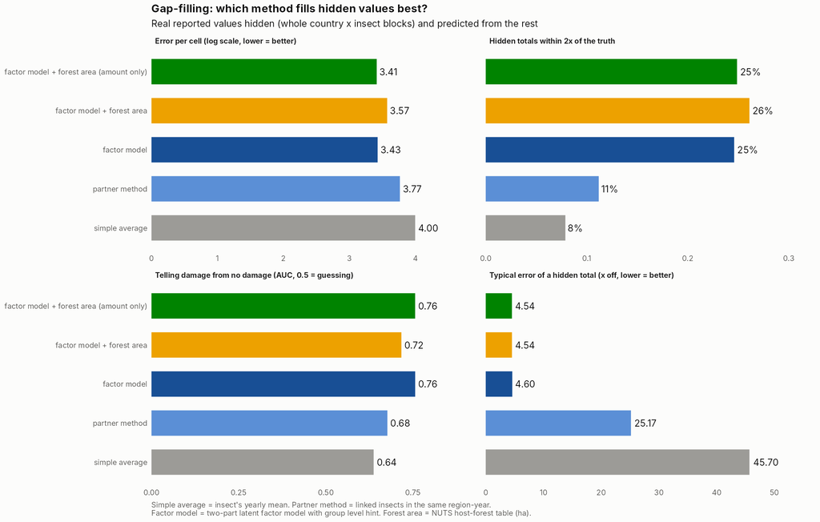

The factor model clearly beats the simple average: it tells damage from no damage much better and gets regional totals far closer.

### A better version of the model (M2)

| Version | Error (lower = better) | Damage vs none (AUC) | Totals within 2x | Typical total off by | Usable pairs the model reproduces |
| --- | --- | --- | --- | --- | --- |
| M0 current | 3.37 | 0.78 | 25% | 4.64x | 13 of 28 |
| M1 region+year (pull 5) | 3.37 | 0.79 | 27% | 4.48x | 14 of 28 |
| M1 region+year (pull 20) | 3.37 | 0.78 | 27% | 4.56x | 16 of 28 |
| M2 K=3 + group links | 3.34 | 0.79 | 27% | 4.35x | 22 of 28 |
| M2 K=4 + group links | 3.34 | 0.79 | 27% | 4.35x | 22 of 28 |
| M2 K=4, no group links | 3.36 | 0.79 | 26% | 4.64x | 13 of 28 |

**M2** (region and year effects separated, 3 hidden factors, insects pulled towards their level-1 group) is the best on every score (AUC 0.79; a hidden regional total typically 4.3x off) and reproduces **22 of the 28** usable pairs instead of 13. It is the model used for the current filled dataset (v3).

### Where insects can live: the range rule

The model first filled insects wherever their tree grows, inventing damage outside their natural range. A draft rule now fills an insect only in countries that report it or border one that does; *T. pityocampa* only in BG, CH, HR, IT and SI (its southern range). The draft table is in `outputs/tables/GF2_range_draft_for_correction.xlsx` for expert correction.

### Europe-wide totals by the paper’s groups (dataset v3)

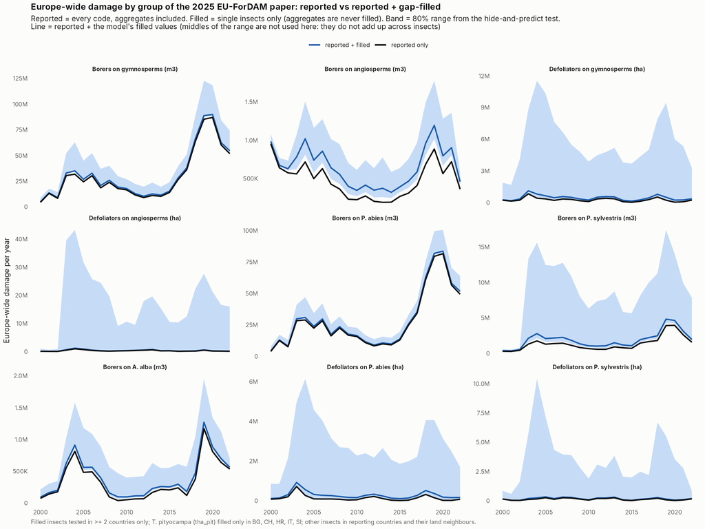

| Level | Group | Unit | Reported 2000-2022 | Filled | Filled vs reported |
| --- | --- | --- | --- | --- | --- |
| 1 | Borers on angiosperms | m3 | 11,000,000 | 4,000,000 | 36% |
| 1 | Borers on gymnosperms | m3 | 690,000,000 | 43,000,000 | 6% |
| 1 | Defoliators on angiosperms | ha | 6,600,000 | 2,000,000 | 30% |
| 1 | Defoliators on gymnosperms | ha | 5,800,000 | 4,200,000 | 72% |
| 2 | Borers on A. alba | m3 | 7,800,000 | 1,300,000 | 17% |
| 2 | Borers on P. abies | m3 | 640,000,000 | 27,000,000 | 4% |
| 2 | Borers on P. sylvestris | m3 | 32,000,000 | 13,000,000 | 40% |
| 2 | Defoliators on P. abies | ha | 3,000,000 | 3,200,000 | 110% |
| 2 | Defoliators on P. sylvestris | ha | 2,900,000 | 980,000 | 34% |

Black = reported only (aggregates included); blue = reported + filled; band = 80% range from the test (it catches the truth about 74% of the time). For borers the filled part is a small top-up (+6% for all borers on gymnosperms, +4% on spruce): the big outbreaks are already reported. For defoliators it is larger (+30-110%), and the ranges are very wide, because defoliator records are patchier and harder to predict.

Per insect: `outputs/figures/GF3_europe_totals_with_ranges.png`.

## 4. How much of the host is killed each year?

Made from the two datasets only: damage from EU-ForDAM (`value1`), host from the NUTS forest appendix.

- **Borers:** % of the host’s growing stock killed = m3 killed / m3 of that tree in the region.
- **Defoliators:** % of the host’s forest area defoliated = ha defoliated / ha of that tree in the region (defoliated, not necessarily killed).
- Only regions and years where the insect has a record (0 included). Regions that do not record an insect are left out of both sides. No gap-filling.
- **Average per year** = all recorded damage / all host of the recorded region-years. **Per year** = that year’s damage / host of the regions recording that year.
- **Host = what the insect feeds on:** specialists their tree (spruce, pine, fir, oak); insects on several trees the wider group (e.g. *L. monacha* all conifers, *Melolontha* all forest).
- **Host trees missing from the forest file:** the EU-ForDAM file gives larch, elm, birch and poplar as hosts for some insects, but the forest appendix only has spruce, pine, oak, fir and the conifer / broadleaf totals. Those insects are divided by all conifers or all broadleaves, so their shares are too small and not comparable with the others.
- Check: no region-year is above 100% of its host; two are above 50% (`SHARE_check_region_years_over_50pct.csv`).

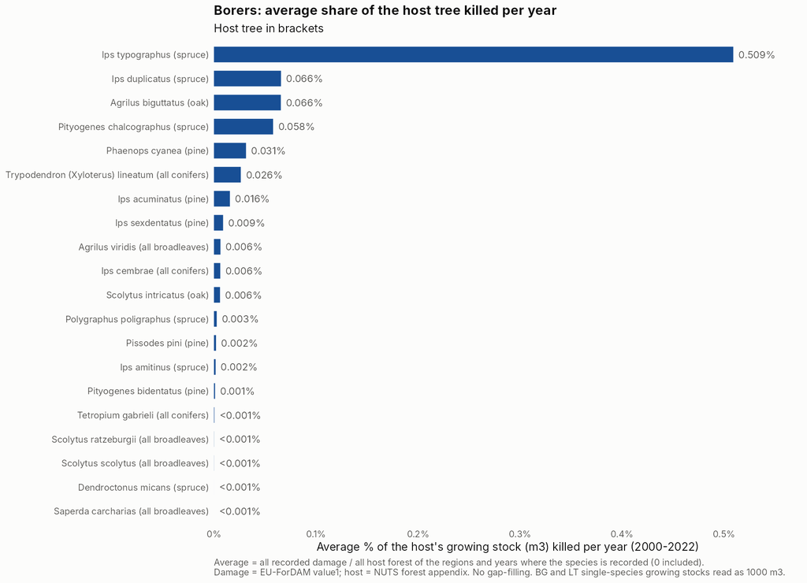

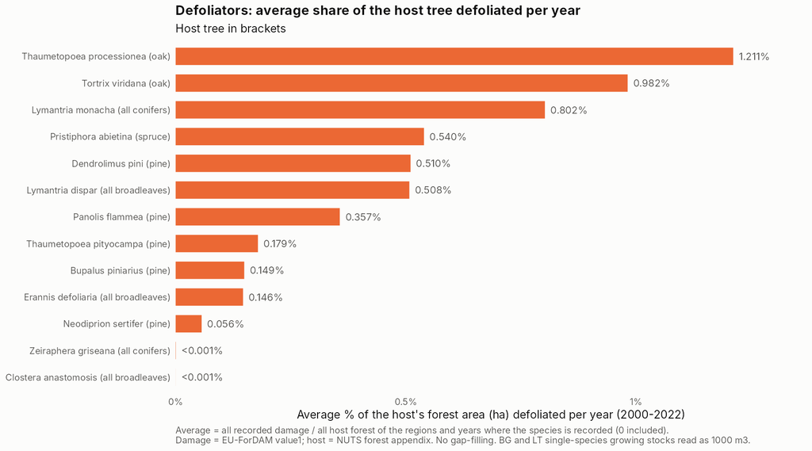

[output not shown]

**Per year, same regions every year.** The regions reporting a species change over time (most countries start in 2003, more German and Czech regions from 2012), which would make lines jump when regions join. The per-year graphs therefore use only the regions that report the species in every year 2003-2021, so the same forest is followed every year (number of regions in each panel title).

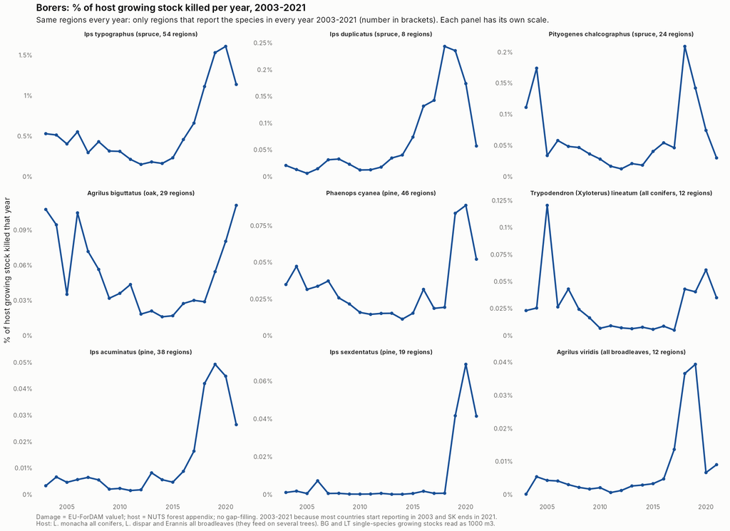

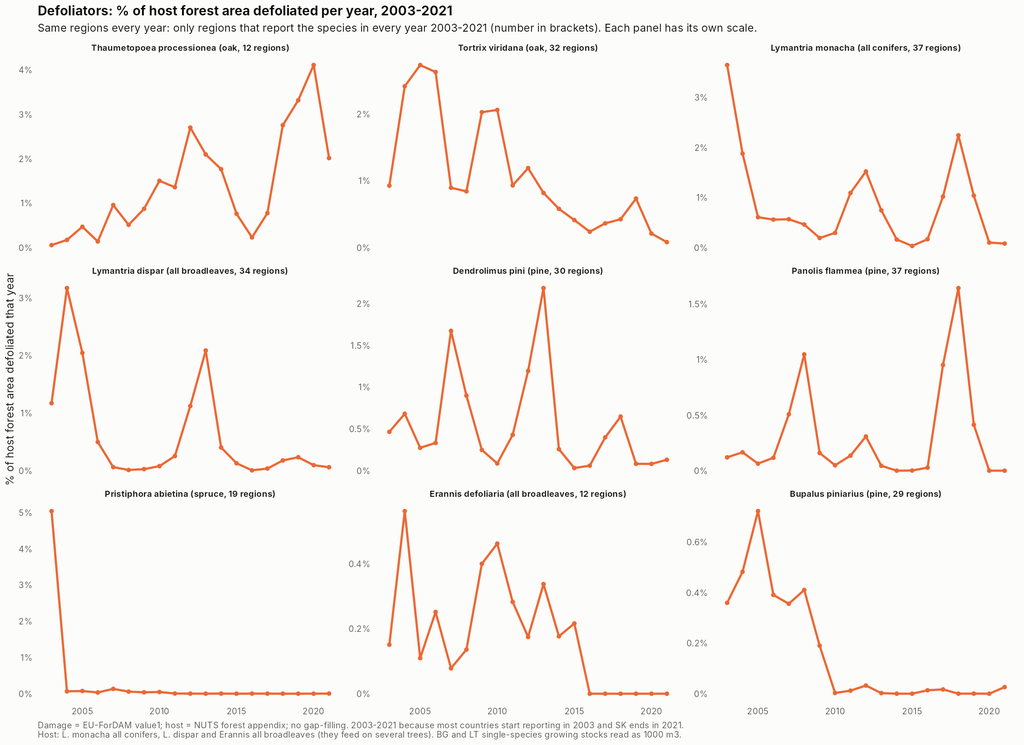

**Open point:** in the appendix the single-species growing stocks of Bulgaria and Lithuania are about 1000x too small for their areas (e.g. BG spruce 31,157 m3 on 133,737 ha). They are read as 1000 m3 here; to be confirmed. Tables: `SHARE_host_affected_average.csv` (average per species), `SHARE_species_by_year.csv` (per species and year).

## Where we stand

[output not shown]

**Open points**

- **Range list**: needs expert checks. Still implausibly high filled damage: *Pissodes pini* (9x reported), *Polygraphus poligraphus* (7x), *Ips duplicatus* (3x).
- **Amounts** are still rough (a regional total is typically about 4x off). Adding drought and storm data is the main expected improvement, and it also answers objective 3 (drivers and anticipation).

## Files

- Reports: `reports/correlation_metrics.html`, `reports/gapfilling.html`
- Figures: `outputs/figures/` (CM_* = correlation metrics, GF* = gap-filling)
- Tables: `outputs/tables/` (e.g. `RANK_groups_level1_level2.csv`, `RANK_species_level3.csv`, `CHECK_totals_vs_paper_table2.csv`, `CM_pairs_verdict.csv`, `CM_groups_level1_level2.csv`, `GF3_europe_totals_by_paper_group.csv`, `GF2_range_draft_for_correction.xlsx`)
- Code-to-group table: `data/lookup/paper_hierarchy_2025.csv`
- Filled dataset (local only): `data/processed/eufordam_gapfilled_v3.csv`